# Week 01 - Kick-Off

Course Setup, Introduction and R-refresher

Welcome to the first session of **Computational Social Sciences**!

Today, we will go over the plan for the semester, including:

- How the course materials are organized
- What the examination requirements are
- How we interact and work together in this course
- And finally, a short optional **R refresher** with some key functions that will be important for us. Those who would like to join are very welcome to stay!

Looking forward to a great semester with you all!

# Introduction round

We will go one by one:

1. Name
2. Place (and field) of Bachelor studies
3. Favorite vegetable
4. Pre-knowledge of R, social network analysis and spatial data analysis
5. General sociological field of interest

# **R**efresher

R is a powerful programming language for statistics, data analysis, and visualization – and best of all, **it’s completely free and open-source!** This means that new functions and packages are constantly being developed by the community, and the latest statistical methods often become available in R first.

One of R’s biggest strengths is its flexibility. Thanks to its **modular package system**, you can easily extend its functionality depending on your needs. Whether you’re collecting, processing, exploring, analyzing, or reporting data, R has you covered at every step of the research process.

R also has an amazing and active community, with groups like **R-Ladies, R Consortium, and rOpenSci** helping to expand and improve it. If you ever need to customize something, you can even write your own functions and share them with others!

Let’s dive in! 🚀

## Getting started

### Installation

In case you haven`t installed R and RStudio

1. Install **R**
2. Install **RStudio**

[figure not shown]

R-Meme (PsyTeachR)

This is the easiest way, you are of course allowed to use other source code editors (like `VSCode`, `Eclipse`, `PyCharm`, `Vim`, `Emacs` or any other preference you might have). I will show the examples in class using RStudio though.

### Start a new file

Create a new R Script, R Notebook, or Quarto document:

1. Go to the menu bar and click on `File`.
2. Select `New File`.
3. Choose the type of file you want to create (R Script, R Notebook, or Quarto document).

**Working directory**:

```r
# Find the current working directory (where inputs are found and output are send)
getwd()

# Change the current working directory
setwd("C://your/file/path")
```

When we analyze data in R usually we also depend on **functions**, other users and developers have written, which are usually stored in so called `packages`. Packages can be installed and called like this:

```r
install.packages("igraph")

library(igraph)
```

#### Accessing help files

```r
# Get help of a particular function
help(rnorm)
# or
?rnorm

# Search te help files for a word or a phrase (if you don't know the name of the function)
help.search("weighted mean")
# or
??"weighted mean"

# Find help for a package
help(package=igraph)
```

There are three fundamental principles that in my point of view help to understand R.

1. **Everything that exists in R is an object!** (Chambers 2017)

In R, all data, from simple numbers to complex models, is treated as an object. This means that every piece of data or function can be stored, manipulated, and passed around. An object can represent variables, functions, or even entire datasets.

2. **Everything that happens in R is the result of a function call** (Chambers 2017)

Whether you are performing basic arithmetic or fitting a stochastic model, every action in R is initiated by a function. This means that every operation can be seen as calling a function that takes input and produces an output. This functional nature of R ensures consistency in how tasks are executed.

```r
# Example:
a <- 5

a

# Function behavior
a <- function(a = 5) {
      a
    }

a()
```

3. **Names have objects; objects don’t have names** (Hadley Wickham 2016)

In R, you don’t *assign values to variables* or *store 5 in x*. Variables in R are not boxes; they don’t contain objects. Instead, you *assign (the variable name) x to 5* or *bind x to 5*. Assignment is simply the association of a name with an object. Any given object may have many names associated with it. At a given instant, a name refers to only one object. Over time, the object a name refers to may vary. (Doane 2018).

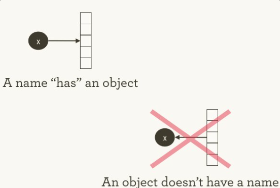

Twitter 2016: @hadleywickham

### Atomic classes in R

Atomic in this case means the data is of size = 1.

[output not shown]

Checking types:

```r
int <- 5L #capital L forces integer-storage
num <- 42.1
log <- TRUE
char <- "Hello"

class(int)
class(num)
class(log)
class(char)
```

### Basic Operations

#### Storage of values

Values can be stored in Variables. The name of a variable starts with a letter and may consist of any sequence of letters, numbers, dot or underline characters.

```r
# assigning values to variables
a <- 15.7
a
a + 10
a / 10
round(a)

# storing results in new variables
b <- round(a)
```

#### Arithmetic operations

```r
# Addition
2 + 7

# Substraction
4 - 2

# Multiplication
5 * 2

# Division
8 / 2

# Natural log
log(2)

# Exponentation
2^3

# Exponential
exp(7)

# Round to nearest integer
floor(4.8)
ceiling(4.8)

# Round
round(7.5)
```

#### Logical operations

```r
# is equal?
b == a

# is unequal?
b != a

# is greater?
b > a

# is smaller?
b < a

# is greater or equal?
b >= a

# is smaller or equal?
b <= a


# Further logical operations
(3 > 2) & (4 > 1)   # AND
(3 > 5) | (1 > 4)   # OR
!TRUE  # NOT
```

## Classes of Data in R

R has several classes that define how data is structured and handled. Just to name a few:

| Class | Description | Example |
| --- | --- | --- |
| vector | Basic 1D array of elements of one type | `c(1, 2, 3)` |
| factor | Categorical data with levels | `factor(c("low", "high"))` |
| matrix | 2D array with elements of one type | `matrix(1:9, nrow = 3)` |
| array | Multi-dimensional generalization of matrix | `array(1:12, dim = c(2,3,2))` |
| list | Collection of different types of objects | `list(name="Alice", age=25)` |
| data.frame | Tabular data, columns can have different types | `data.frame(a=1:3, b=c("x","y","z"))` |
| tibble | Enhanced version of a data frame | `tibble::tibble(a=1:3, b=c("x","y","z"))` |

#### Vectors

A vector is a simple data structure, that can store multiple elements of the same type. You can create a vector using the `c()` function.

To ensure, that all elements in a vector are of the same type, R will coerce the elements to the most general type. For example, if you combine a numeric and a character, the numeric will be coerced to a character.

```r
ages <- c(25, 30, 35, 40)
names <- c("Albert", "Berta", "Charlie", "Dora")
sociologists <- c(TRUE, FALSE, TRUE, FALSE)
```

##### Indexication

**R indices start counting at 1**, not at 0 like in many other programming languages. You can access elements of a vector, matrix, or data frame by using square brackets `[]`.

```r
# Accessing elements of a vector
ages[1]
names[2]
sociologists[3]
ages[c(1,4)] # First and fourth element
names[-1] #  All but the first element
names[names == "Tom"] #  All elements with the name "Tom"
ages[names == "Tom"] # Age of the person with the name "Tom"
```

**Short Exercise:**

1. What are the names of the sociologists?
2. What are the ages of the non-sociologists?
3. Are Berta and Charlie sociologists?

#### Factors

Factors are vectors that represent categorical data. They can be ordered (e.g. low, medium, high) or unordered (female, male, divers). Underlying they are represented by numbers.

Factors are especially important for modelling functions like ‘lm’ and ‘glm’.

#### Matrices

Matrices are two-dimensional arrays with elements of the same type. You can create a matrix using the `matrix()` function.

```r
M <- matrix(c(11, 0, 3, 3, 5, 1, 7, 1, 0),
      nrow = 3)
M

N <- matrix(1:9,
      nrow = 3)
N
```

##### Indexication

```r
M[1, 2] # First row, second column
M[1, ]   # First row
M[, 2]   # Second column

# name the row of a matrix
rownames(M) <- c("A", "B", "C")

# name the column of a matrix
colnames(M) <- c("A", "B", "C")
```

#### Data frames

Data frames are one of the most common data structures in R. They are two-dimensional objects, with rows and columns. Each column can have a different type. You can create a data frame using the `data.frame()` function.

```r
df_friends <- data.frame(name = names,
                         religious = religious,
                         age = ages)
df_friends
```

##### Indexication

```r
df_friends[3,]   # Dritte Zeile

df_friends[,2]   # Zweite Spalte

df_friends[3,2]  # Drittes Element in der zweiten Spalte

df_friends$name  # Zugriff auf eine Spalte per Namen
```

##### Add variables

```r
year_of_birth <- 2025 - df_friends$age
df_friends$birth_year <- year_of_birth

df_friends$city <- c("Leipzig", "Leipzig", "Berlin", "Leipzig")
df_friends
```

#### Lists

Lists are collections of different types of objects. You can create a list using the `list()` function.

```r
friends_list <- list(
  name = df_friends$name,
  age = df_friends$age,
  city = df_friends$city,
  birth_year = df_friends$birth_year,
  sociologists = df_friends$sociologists
)

friends_list
```

##### Indexication

```r
friends_list$name # Index via name
friends_list[1] # gives list(list())
friends_list[[1]] # Index via position | gives objects in list


# Further indexing

list_of_list <- list(
  l1 = friends_list,
  l2 = list("something else",
            c(1:1000))
)

# If you want to go deeper in the structure, you can use more [[]].
list_of_lists$l1$name
list_of_lists[[1]][[1]] # first element from first list
list_of_lists[[2]]
```

In addition to this positive indexication, we can also use negative indices. For example ‘friends_list[-1]’ gives all elements, but the first.

[figure not shown]

Unlist-meme (R-Memes for Statistical Friendss - Facebook 2017)

## Operations

We can perform several operations on different classes of vectors or variables. If we want to call variables we use the name of the object followed by the `$` sign and the name of the variable.

```r
# give mimum value
min(vec)

# give maximum value
max(vec)

# give mean value
mean(vec)

# give median value
median(vec)

# give standard deviation
sd(vec)

# give sum of all values
sum(vec)

# give length of vector
length(vec)

# give range of vector
range(vec)

# give quantile of vector
quantile(vec)

# give unique values of vector
unique(vec)

# give number of unique values
length(unique(vec))

# give frequency of values
table(vec)

# This works also with variables.
mean(my_data$score)
```

## Control structures

Control structures are used to control the flow of a program. They include loops and conditional statements.

**Tip**:

There are two tips, that will make your programming game a whole lot easier:

1. Don`t repeat yourself: If you find yourself writing the same code over and over again, you should consider automating your task.
2. Divide and conquer: If you have a complex task, break it down into smaller, more manageable parts.

#### If-loops

A if-loop is useful to discern between different cases. The syntax is as follows

If (condition) {  
# do something  
} else {  
# do something else  
}

If the condition (**logical value**) is true, the code in the first block will be executed. Otherwise, the code in the second block will be executed.

```r
x <- 10

if (x > 0) {
  print(TRUE)
} else {
  print(FALSE)
}
```

For simple vector-based operations, you can use the `ifelse()` function. It has the following structure: `ifelse(condition, value if true, value if false)`.

```r
birthyear <- c(1991, 1984, 1969, 2004, 1988, 2007, 1996)

ifelse(birthyear < 1996, "other", "Generation Z")
```

#### Loops

There are two main types of loops in R: `for` and `while` loops. 1. `for (i in I) {code execution}`: The `for` loop is used to iterate over a sequence of values in a set. 2. `while (condition) {code execution}`: The `while` loop is used to execute a block of code as long as a condition is true.

**Example:** Compute how long a person still has to work until retirement (for-loop)

```r
ages <- c(21, 29, 61, 72, 12)

for (i in ages) {
  if (i >= 67) {
    print("retired")
  }
  if (i < 18) {
    print("in education")
  }
  if (i > 18 & i < 67) {
    rest <- 67 - i
    print(rest)
  }
}
```

**Example:** Compute how long a person can drink, staying below a certain alcohol level and not spending more than a certain amount of money (while-loop)

```r
money <- 25
alcohol <- 0

while (money >= 3 & alcohol < 1.2) {

    money <- money - 3
    alcohol <- alcohol + 0.3

    print(paste0("Money spent: ", money))
    print(paste0("Alcohol in blood: ", alcohol))

}
```

#### Functions

Sometimes, we want to repeat a certain task multiple times. In this case, we can write a function. Functions are blocks of code that perform a specific task. They can take arguments as input and return a value as output. The syntax follows: `function_name <- function(argument) {function body}`

When doing this, the function is loaded as an object to the global environment.

```r
# Creating and using functions
my_function <- function(x) {

  y <- x^2 + 3

  return(y)
}

my_function(5)  # Example usage
```

**Apply functions** The family of `apply` functions is used to apply a function to the rows or columns of a matrix or data frame. The most common functions are `apply()`, `lapply()`, `sapply()`, and `tapply()`. In principle, they are a more efficient variant of for-loops running a function FUN over a vector or list X. Most often, we use lapply() which returns a list of outputs (one entry per part in X).

```r
nums <- c(1:10)
new_nums <- lapply(X = nums, # run over nums
                   FUN = my_function) # run my_function


new_nums
```

**Exercise**:

The machine processes a list of employees (Stephan, Sascha, Leo, Julius and Felix), where each entry is a vector with three values.

- The number of cups of coffee already drunk.
- Their individual caffeine tolerance (number between 1 and 10)
- Whether they are currently tired. Each coffee brings a 40% chance of feeling more awake afterwards.

The machine should apply the following rules.

1. if someone has drunk more cups than their tolerance, they will not get another cup of coffee.
2. if someone is tired, they are given coffee until they are awake (after a maximum of three cups) or until their tolerance is exceeded.
3. everyone else gets another cup.

The function should output a new list with the updated coffee values and the new awake status and say whether the persons have received a coffee and whether they will get another one on the next attempt.

Leo can take 4 cups of coffee, Stephan 4, Sascha 7, Julius 9 and Felix 2 [^1]. Everybody has had two coffees already but are still feeling pretty tired.

**Work in teams to rewrite the algorithm!**

## Global environment

The global environment is the workspace of R. It contains all objects that you have created during your session. You can see all objects in the global environment in the upper right corner of RStudio. You can also list all objects in the global environment using the `ls()` function.

```r
ls()

# delete specific object
rm(df_friends)

# delete global environment
rm(list = ls())

# Save objects in global environment
# Save data
save(df_friends, file = "files/df_friends.RData")

# Load data
load("files/df_friends.RData")
```

That is about it. If you have any questions during the semester, feel free to ask! You can also always come back to this document to refresh your memory.

**Homework**

Please install the packages `igraph`, `ggplot2`, `ggraph` in your R environment.

# Further **R**esources

As always: If you know cool materials or find it during the path of this course, don’t hesitate to send it to me!

If you need a further overview - Check out these cheat sheets:

- [RStudio IDE Cheatsheet](https://rstudio.github.io/cheatsheets/rstudio-ide.pdf)
- [Publish and Share with Quarto](https://rstudio.github.io/cheatsheets/quarto.pdf)
- [R for Datascience] (https://r4ds.had.co.nz/)

Or if you are generally interested in coding (*in Python*):

https://missing.csail.mit.edu/

## References

Chambers, John M. 2017. *Extending R*. CRC Press.

Doane, William. 2018. “Three Deep Truths About R.” *William E. J. Doane PhD*. http://DrDoane.com/?p.

Hadley Wickham. 2016. “In #Rstats, It’s Surprisingly Important to Realise That Names Have Objects; Objects Don’t Have Names https://t.co/bEMO1YVZX0.” Tweet. *Twitter*.

## Footnotes

[^1]: Names and caffeine tolerance are defined at random.

## Copyright

Copyright Leonie Steinbrinker, 2025. All Rights Reserved